# assignment_3_market

Queenie

09/03/2021

Instacart Market Basket Analysis dataset obtained from https://www.kaggle.com/c/instacart-market-basket-analysis/data (https://www.kaggle.com/c/instacart-market-basket-analysis/data)

The goal of the competition is to predict which products will be in a user’s next order.

```r
# aisles <- read.csv("aisles.csv")
# department <- read.csv("departments.csv")
# orders <- read.csv("orders.csv")
# order_products_prior <- read.csv("order_products__prior.csv")
# order_products_train <- read.csv("order_products__train.csv")
# products <- read.csv("products.csv")
# sample_submission <- read.csv("sample_submission.csv")
```

Read in the merged training data set:

```r
X <- read.csv("C:/Users/qt09n/Desktop/Project/orders_TRAIN_products_MERGED.csv")
```

```r
str(X)
```

```
## 'data.frame':    1384617 obs. of  16 variables:
##  $ order_id              : num  1 1 1 1 1 1 1 1 36 36 ...
##  $ user_id               : num  112108 112108 112108 112108 112108 ...
##  $ eval_set              : chr  "train" "train" "train" "train" ...
##  $ order_number          : int  4 4 4 4 4 4 4 4 23 23 ...
##  $ order_dow             : int  4 4 4 4 4 4 4 4 6 6 ...
##  $ order_hour_of_day     : int  10 10 10 10 10 10 10 10 18 18 ...
##  $ days_since_prior_order: int  9 9 9 9 9 9 9 9 30 30 ...
##  $ product_id            : int  10246 11109 22035 47209 13176 49302 49683 43633 39612 46620 ...
##  $ add_to_cart_order     : int  3 2 8 7 6 1 4 5 1 5 ...
##  $ reordered             : int  0 1 1 0 0 1 0 1 0 1 ...
##  $ product_name          : chr  "Organic Celery Hearts" "Organic 4% Milk Fat Whole Milk Cottage Cheese" "Organic Whole String Cheese" "Organic Hass Avocado" ...
##  $ aisle                 : chr  "fresh vegetables" "other creams cheeses" "packaged cheese" "fresh fruits" ...
##  $ department            : chr  "produce" "dairy eggs" "dairy eggs" "produce" ...
##  $ aisle_id              : int  83 108 21 24 24 120 83 95 2 86 ...
##  $ department_id         : int  4 16 16 4 4 16 4 15 16 16 ...
##  $ X_merge               : int  3 3 3 3 3 3 3 3 3 3 ...
```

Check missing values: complete.cases will return a logical vector indicating which rows have no missing values. Then use the vector to get only complete rows with X[,]

```r
X <- X[complete.cases(X),]
```

```r
head(X)
```

|  | order_id | user_id | eval_set | order_number | order_dow | order_hour_of_day | days_since_prior_order | product_id | add_to_cart_order | reordered | product_name | aisle | department | aisle_id | department_id | X_merge |
| --- | --- | --- | --- | --- | --- | --- | --- | --- | --- | --- | --- | --- | --- | --- | --- | --- |
| 1 | 1 | 112108 | train | 4 | 4 | 10 | 9 | 10246 | 3 | 0 | Organic Celery Hearts | fresh vegetables | produce | 83 | 4 | 3 |
| 2 | 1 | 112108 | train | 4 | 4 | 10 | 9 | 11109 | 2 | 1 | Organic 4% Milk Fat Whole Milk Cottage Cheese | other creams cheeses | dairy eggs | 108 | 16 | 3 |
| 3 | 1 | 112108 | train | 4 | 4 | 10 | 9 | 22035 | 8 | 1 | Organic Whole String Cheese | packaged cheese | dairy eggs | 21 | 16 | 3 |
| 4 | 1 | 112108 | train | 4 | 4 | 10 | 9 | 47209 | 7 | 0 | Organic Hass Avocado | fresh fruits | produce | 24 | 4 | 3 |
| 5 | 1 | 112108 | train | 4 | 4 | 10 | 9 | 13176 | 6 | 0 | Bag of Organic Bananas | fresh fruits | produce | 24 | 4 | 3 |
| 6 | 1 | 112108 | train | 4 | 4 | 10 | 9 | 49302 | 1 | 1 | Bulgarian Yogurt | yogurt | dairy eggs | 120 | 16 | 3 |

```r
summary(X)
```

```
##     order_id          user_id         eval_set          order_number
##  Min.   :      1   Min.   :     1   Length:1384617     Min.   :  4.00
##  1st Qu.: 843370   1st Qu.: 51732   Class :character   1st Qu.:  6.00
##  Median :1701880   Median :102933   Mode  :character   Median : 11.00
##  Mean   :1706298   Mean   :103113                      Mean   : 17.09
##  3rd Qu.:2568023   3rd Qu.:154959                      3rd Qu.: 21.00
##  Max.   :3421070   Max.   :206209                      Max.   :100.00
##    order_dow     order_hour_of_day days_since_prior_order   product_id
##  Min.   :0.000   Min.   : 0.00     Min.   : 0.00          Min.   :    1
##  1st Qu.:1.000   1st Qu.:10.00     1st Qu.: 7.00          1st Qu.:13380
##  Median :3.000   Median :14.00     Median :15.00          Median :25298
##  Mean   :2.701   Mean   :13.58     Mean   :17.07          Mean   :25556
##  3rd Qu.:5.000   3rd Qu.:17.00     3rd Qu.:30.00          3rd Qu.:37940
##  Max.   :6.000   Max.   :23.00     Max.   :30.00          Max.   :49688
##  add_to_cart_order   reordered      product_name          aisle
##  Min.   : 1.000    Min.   :0.0000   Length:1384617     Length:1384617
##  1st Qu.: 3.000    1st Qu.:0.0000   Class :character   Class :character
##  Median : 7.000    Median :1.0000   Mode  :character   Mode  :character
##  Mean   : 8.758    Mean   :0.5986
##  3rd Qu.:12.000    3rd Qu.:1.0000
##  Max.   :80.000    Max.   :1.0000
##   department           aisle_id     department_id      X_merge
##  Length:1384617     Min.   :  1.0   Min.   : 1.00   Min.   :3
##  Class :character   1st Qu.: 31.0   1st Qu.: 4.00   1st Qu.:3
##  Mode  :character   Median : 83.0   Median : 8.00   Median :3
##                     Mean   : 71.3   Mean   : 9.84   Mean   :3
##                     3rd Qu.:107.0   3rd Qu.:16.00   3rd Qu.:3
##                     Max.   :134.0   Max.   :21.00   Max.   :3
```

```r
X$product_name <- as.factor(X$product_name)
X$department<- as.factor(X$department)
X$aisle <- as.factor(X$aisle)
```

```r
unique(X$aisle)
```

```
##   [1] fresh vegetables              other creams cheeses
##   [3] packaged cheese               fresh fruits
##   [5] yogurt                        canned meat seafood
##   [7] specialty cheeses             eggs
##   [9] lunch meat                    cream
##  [11] water seltzer sparkling water packaged vegetables fruits
##  [13] oils vinegars                 fresh herbs
##  [15] frozen produce                nuts seeds dried fruit
##  [17] canned meals beans            food storage
##  [19] baking ingredients            hot dogs bacon sausage
##  [21] refrigerated                  plates bowls cups flatware
##  [23] butter                        canned jarred vegetables
##  [25] paper goods                   fresh dips tapenades
##  [27] soup broth bouillon           dish detergents
##  [29] tortillas flat bread          condiments
```

[output cut: 53 more lines]

```r
#134 aisles
```

```r
unique(X$department)
```

```
##  [1] produce         dairy eggs      canned goods    deli
##  [5] beverages       pantry          frozen          snacks
##  [9] household       meat seafood    bakery          personal care
## [13] dry goods pasta babies          other           missing
## [17] breakfast       international   alcohol         bulk
## [21] pets
## 21 Levels: alcohol babies bakery beverages breakfast bulk ... snacks
```

```r
levels(X$department)
```

```
##  [1] "alcohol"         "babies"          "bakery"          "beverages"
##  [5] "breakfast"       "bulk"            "canned goods"    "dairy eggs"
##  [9] "deli"            "dry goods pasta" "frozen"          "household"
## [13] "international"   "meat seafood"    "missing"         "other"
## [17] "pantry"          "personal care"   "pets"            "produce"
## [21] "snacks"
```

```r
#21 departments
```

```r
length(unique(X$product_name))
```

```
## [1] 39123
```

```r
#39123 products
```

```r
class(X$order_hour_of_day)
```

```
## [1] "integer"
```

```r
#[1] "integer"
```

How many unique orders are in the training dataset?

```r
length(unique(X$order_id))
```

```
## [1] 131209
```

How many users are in the training dataset?

```r
length(unique(X$user_id))
```

```
## [1] 131209
```

So it looks like the number of users are the same as the number of orders…

Recode order_hour_of_day to numeric:

```r
X$order_hour_of_day <- as.numeric(X$order_hour_of_day)
```

Look at when people order:

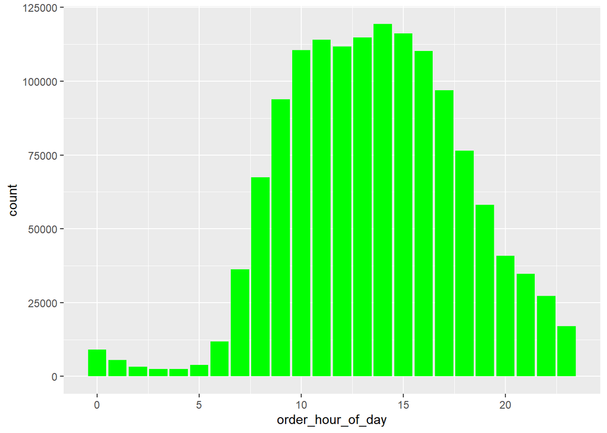

```r
X %>% ggplot(aes(x= order_hour_of_day)) +
  geom_bar(stat="count", fill="green")
```

People mostly order from 8:00 - 17:00 (8AM - 5PM).

Most frequently bought products

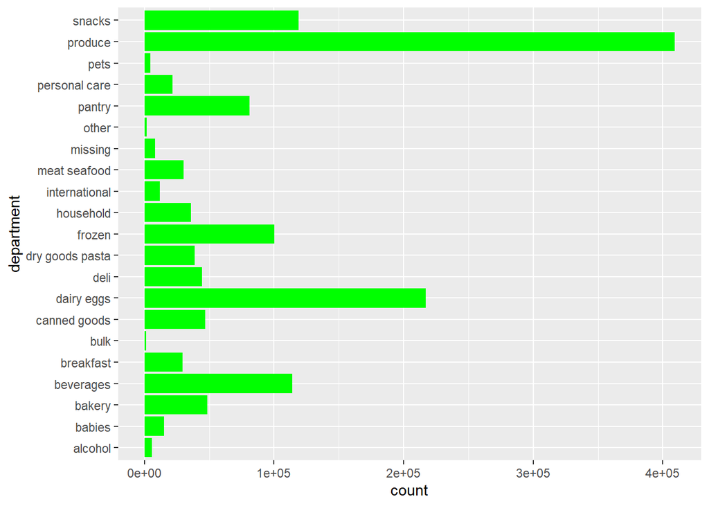

```r
X %>% ggplot(aes(x= department)) +
  geom_histogram(stat="count", fill="green")+
  coord_flip()
```

Most orders come from the produce aisle, with snacks and dairy, eggs among the top 3 department aisles.

‘order_dow’ is the day of week. Which days are orders more commonly placed on?

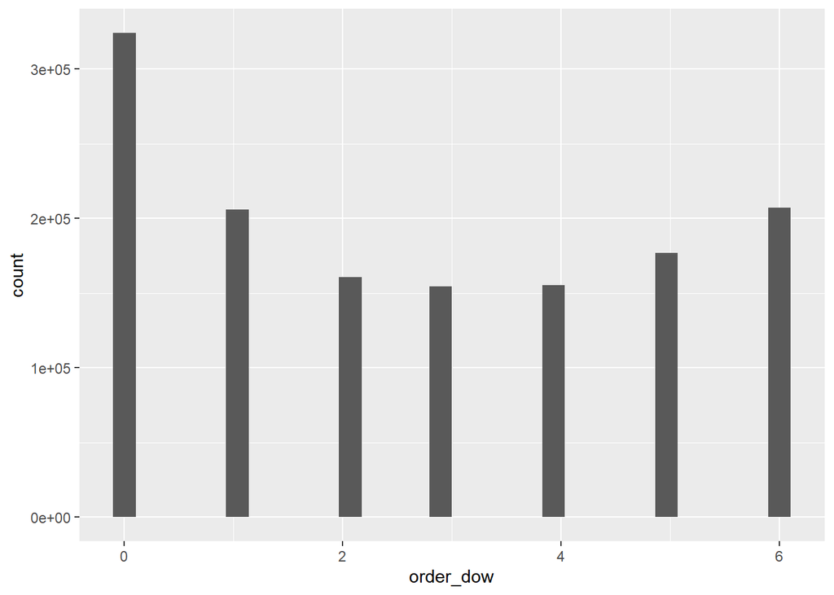

```r
X %>% ggplot(aes(x=order_dow))+
      geom_histogram()
```

```r
#Sunday, Monday and Saturday appear to be the most common days where people place their orders.
```

How many days pass between an order and the next order?

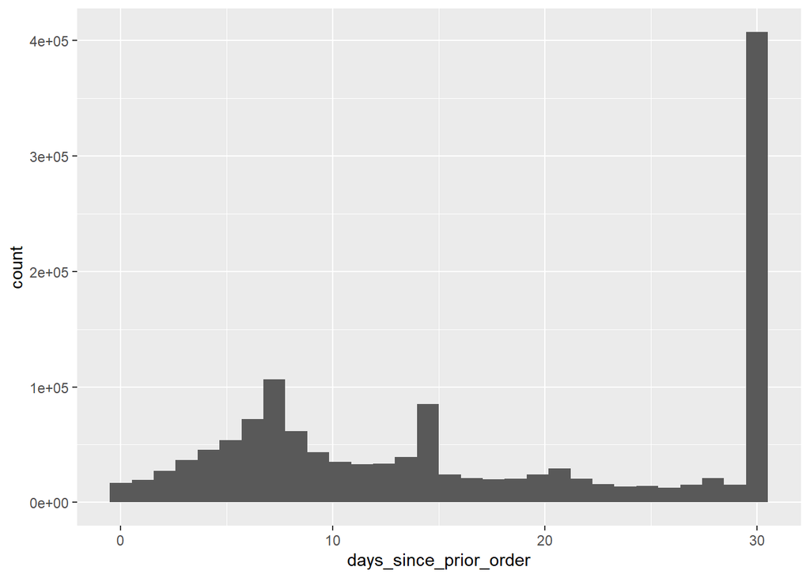

```r
X %>% ggplot(aes(x=days_since_prior_order))+
      geom_histogram()
```

People most commonly order again after 30 days (1 month), or 7 days (1 week).

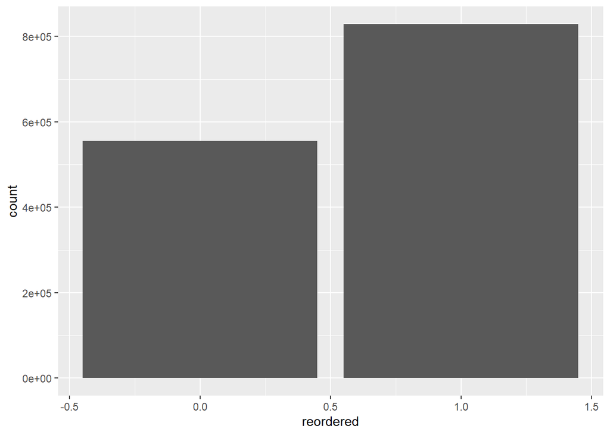

```r
  ggplot(X) +
geom_bar(mapping= aes(x=reordered))
```

X_merge column is not needed for association rule mining, so can set to NULL:

```r
X$X_merge <- NULL
```

Need to convert dataframe to transaction data so that all items bought together in one order is in one row. Currently different products from the same order are in their own rows (singles format).

```r
library(plyr)
#ddply(dataframe, variables_to_be_used_to_split_data_frame, function_to_be_applied)

transactionData <- ddply(X, c("order_id","user_id"),
                       function(df1)paste(df1$product_name,     #paste is used to concatenate vectors to       characters
                       collapse = ","))     #collapse is used to separate the concatenated product names with a comma
```

Look at the transaction data. This is currently in the form of a basket format:

| order_id | user_id | V1 |
| --- | --- | --- |
| 1 | 112108 | Organic Celery Hearts,Organic 4% Milk Fat Whole Milk Cottage Cheese,Organic Whole String Cheese,Organic Hass Avocado,Bag of Organic Bananas,Bulgarian Yogurt,Cucumber Kirby,Lightly Smoked Sardines in O… |
| 36 | 79431 | Grated Pecorino Romano Cheese,Cage Free Extra Large Grade AA Eggs,Asparagus,Prosciutto, Americano,Organic Garnet Sweet Potato (Yam),Organic Half & Half,Spring Water,Super Greens Salad |
| 38 | 42756 | Organic Hot House Tomato,Organic Baby Arugula,Organic Raw Unfiltered Apple Cider Vinegar,Flat Parsley, Bunch,Fresh Dill,Green Peas,Shelled Pistachios,Bunched Cilantro,Organic Biologique Limes |
| 96 | 17227 | Organic Cucumber,Organic Grape Tomatoes,Roasted Turkey,Organic Pomegranate Kernels,Organic Whole Strawberries,Organic Blueberries,Organic Raspberries |
| 98 | 56463 | Organic Stringles Mozzarella String Cheese,Pinto Beans No Salt Added,Bag of Organic Bananas,Organic Extra Virgin Oil Olive,Aluminum Foil,100% Organic Unbleached All-Purpose Flour,Uncured Applewood Smo… |
| 112 | 125030 | Sea Salt Baked Potato Chips,Umcka Elderberry Intensive Cold + Flu Berry Flavor,Baked Sea Salt & Vinegar Potato Chips,Organic Hass Avocado,Coconut Water Kefir,Premium Epsom Salt,Marinara Pasta Sauce,Or… |
| 170 | 182389 | 100% Whole Wheat Bread,Baby Spinach,Brown Rice,Xpolsive Pizza Baked Snack Crackers,BBQ Ranch Chopped Salad,Natural Creamy Peanut Butter Spread,Organic Strawberries,California Clementines,Classic Movie… |
| 218 | 98711 | Organic Yellow Peaches,Black Plum,Natural Artisan Water,Citrus Mandarins Organic,Okra |
| 226 | 51011 | Blackberry Cucumber Sparkling Water,Organic Blueberries,Vitamin D Whole Milk,Wrap Aluminum Foil Heavy Duty,Take & Toss 10oz Cups w/ Straws,Organic 2% Reduced Fat Milk,Maximum Strength Original Paste D… |
| 349 | 156353 | Organic Beef Hot Dogs,Pure Almond Unsweetened Original Almond Milk,Natural Chicken & Sage Breakfast Sausage,Organic Medium Brown Eggs,Uncured Hickory Smoked Sunday Bacon,Organics Vitamin C Fortified 1… |

[output cut: 9990 more lines]

#set order id and user id to NULL in the transaction dataset since it will not be needed for item association

```r
transactionData$order_id <- NULL
transactionData$user_id <- NULL
```

rename column to items

```r
colnames(transactionData) <- c("items")
```

write the transaction data csv into a csv file:

```r
#write.csv(transactionData,"C:/Users/qt09n/Desktop/Project/market_basket_transactions.csv", quote = FALSE, row.names = FALSE)
```

```r
tr
```

```
## transactions in sparse format with
##  131210 transactions (rows) and
##  50153 items (columns)
```

```r
summary(tr)
```

```
## transactions as itemMatrix in sparse format with
##  131210 rows (elements/itemsets/transactions) and
##  50153 columns (items) and a density of 0.00020449
##
## most frequent items:
##                 Banana Bag of Organic Bananas   Organic Strawberries
##                  17724                  14597                  10260
##   Organic Baby Spinach            Large Lemon                (Other)
##                   9318                   7740                1286023
##
## element (itemset/transaction) length distribution:
## sizes
##    1    2    3    4    5    6    7    8    9   10   11   12   13   14   15   16
## 7750 8047 8474 8470 8887 8684 8471 7856 7104 6447 5943 5356 4770 4219 3645 3364
##   17   18   19   20   21   22   23   24   25   26   27   28   29   30   31   32
## 3073 2617 2390 2020 1771 1560 1408 1245 1085  932  812  637  557  553  434  387
##   33   34   35   36   37   38   39   40   41   42   43   44   45   46   47   48
##  299  289  246  190  178  151  126  116   84   82   71   63   49   43   35   28
##   49   50   51   52   53   54   55   56   57   58   59   60   61   62   63   65
##   21   22   20   23   17   13    8   11    5    5    5    8    5    3    3    1
##   66   67   68   69   72   75   76   78   80   82   84
##    4    3    2    5    1    1    1    2    1    1    1
##
##    Min. 1st Qu.  Median    Mean 3rd Qu.    Max.
##    1.00    5.00    8.00   10.26   14.00   84.00
##
## includes extended item information - examples:
##                         labels
## 1                           #2
## 2            #2 Coffee Filters
## 3 #2 Cone White Coffee Filters
```

To calculate how many items were purchased: 131210 x 50153 x 0.00020449 = 1345662

A sparse matrix is a matrix in which most elements are zero.

## References

https://www.datacamp.com/community/tutorials/market-basket-analysis-r#code